# Assignment 2: Spatial Analysis and Visualization

Healthcare Access and Equity in Pennsylvania

Author

Itsnatani Humaira Anaqami

Published

October 5, 2025

## Assignment Overview

**Learning Objectives:** - Apply spatial operations to answer policy-relevant research questions - Integrate census demographic data with spatial analysis - Create publication-quality visualizations and maps - Work with spatial data from multiple sources - Communicate findings effectively for policy audiences

## Part 1: Healthcare Access for Vulnerable Populations

### Research Question

**Which Pennsylvania counties have the highest proportion of vulnerable populations (elderly + low-income) living far from hospitals?**

Your analysis should identify counties that should be priorities for healthcare investment and policy intervention.

### Required Analysis Steps

Complete the following analysis, documenting each step with code and brief explanations:

#### Step 1: Data Collection (5 points)

Load the required spatial data: - Pennsylvania county boundaries - Pennsylvania hospitals (from lecture data) - Pennsylvania census tracts

**Your Task:**

```r
# Load required packages
library(sf)
library(tidyverse)
library(tigris)
library(tidycensus)
library(dplyr)
library(tidyr)
library(scales)
library(patchwork)
library(here)
options(tigris_use_cache = TRUE)
options(tigris_progress = FALSE)  # Suppress tigris progress bars

# Set your Census API key
census_api_key(Sys.getenv("your_API_key"))

# Load spatial data
pa_counties <- st_read(here("assignments/assignment2/scripts/data/Pennsylvania_County_Boundaries.shp"))
hospitals <- st_read(here("assignments/assignment2/scripts/data/hospitals.geojson"))
census_tracts <- tracts(state = "PA", cb = TRUE, progress = FALSE)

# Standardize CRS
st_crs(pa_counties)
```

[output not shown]

```r
hospitals <- st_transform(hospitals, st_crs(pa_counties))
census_tracts <- st_transform(census_tracts, st_crs(pa_counties))

# Check that all data loaded correctly
head(pa_counties)
```

```
Simple feature collection with 6 features and 19 fields
Geometry type: MULTIPOLYGON
Dimension:     XY
Bounding box:  xmin: -8905670 ymin: 4862594 xmax: -8317930 ymax: 5161279
Projected CRS: WGS 84 / Pseudo-Mercator
  OBJECTID MSLINK COUNTY_NAM COUNTY_NUM FIPS_COUNT COUNTY_ARE COUNTY_PER
1      336     46 MONTGOMERY         46        091       <NA>       <NA>
2      337      8   BRADFORD         08        015       <NA>       <NA>
3      338      9      BUCKS         09        017       <NA>       <NA>
4      339     58      TIOGA         58        117       <NA>       <NA>
5      340     59      UNION         59        119       <NA>       <NA>
6      341     60    VENANGO         60        121       <NA>       <NA>
  NUMERIC_LA COUNTY_N_1 AREA_SQ_MI SOUND SPREAD_SHE IMAGE_NAME NOTE_FILE VIDEO
1          5         46   487.4271  <NA>       <NA>   poll.bmp      <NA>  <NA>
2          2          8  1161.3379  <NA>       <NA>   poll.bmp      <NA>  <NA>
3          5          9   622.0836  <NA>       <NA>   poll.bmp      <NA>  <NA>
4          2         58  1137.2480  <NA>       <NA>   poll.bmp      <NA>  <NA>
5          2         59   319.1893  <NA>       <NA>   poll.bmp      <NA>  <NA>
6          3         60   683.3676  <NA>       <NA>   poll.bmp      <NA>  <NA>
  DISTRICT_N PA_CTY_COD MAINT_CTY_ DISTRICT_O                       geometry
1         06         46          4        6-4 MULTIPOLYGON (((-8398884 48...
2         03         08          9        3-9 MULTIPOLYGON (((-8558633 51...
3         06         09          1        6-1 MULTIPOLYGON (((-8367360 49...
4         03         59          7        3-7 MULTIPOLYGON (((-8558633 51...
5         03         60          8        3-8 MULTIPOLYGON (((-8562865 49...
6         01         61          5        1-5 MULTIPOLYGON (((-8870781 50...
```

```r
head(hospitals)
```

```
Simple feature collection with 6 features and 11 fields
Geometry type: POINT
Dimension:     XY
Bounding box:  xmin: -8936626 ymin: 4838244 xmax: -8367892 ymax: 4901278
Projected CRS: WGS 84 / Pseudo-Mercator
                 CHIEF_EXEC              CHIEF_EX_1
1             Peter J Adamo               President
2          Autumn DeShields Chief Executive Officer
3              Shawn Parekh Chief Executive Officer
4               DIANE HRITZ Chief Executive Officer
5            Tim Harclerode Chief Executive Officer
6 Richard McLaughlin MD MBA Chief Executive Officer
                      FACILITY_U LONGITUDE       COUNTY
1   https://www.phhealthcare.org -79.91131   Washington
2      https://www.malvernbh.com -75.17005 Philadelphia
```

[output cut: 18 more lines]

```r
head(census_tracts)
```

```
Simple feature collection with 6 features and 13 fields
Geometry type: MULTIPOLYGON
Dimension:     XY
Bounding box:  xmin: -8730207 ymin: 4835980 xmax: -8446959 ymax: 4945207
Projected CRS: WGS 84 / Pseudo-Mercator
  STATEFP COUNTYFP TRACTCE             AFFGEOID       GEOID   NAME
1      42      001  031101 1400000US42001031101 42001031101 311.01
2      42      013  100400 1400000US42013100400 42013100400   1004
3      42      013  100300 1400000US42013100300 42013100300   1003
4      42      013  100800 1400000US42013100800 42013100800   1008
5      42      011  000100 1400000US42011000100 42011000100      1
6      42      011  012200 1400000US42011012200 42011012200    122
             NAMELSAD STUSPS   NAMELSADCO   STATE_NAME LSAD   ALAND AWATER
1 Census Tract 311.01     PA Adams County Pennsylvania   CT 3042633      0
2   Census Tract 1004     PA Blair County Pennsylvania   CT  993724      0
3   Census Tract 1003     PA Blair County Pennsylvania   CT 1217046      0
4   Census Tract 1008     PA Blair County Pennsylvania   CT  996553      0
5      Census Tract 1     PA Berks County Pennsylvania   CT  807871      0
6    Census Tract 122     PA Berks County Pennsylvania   CT 2788188  30830
                        geometry
1 MULTIPOLYGON (((-8575060 48...
2 MULTIPOLYGON (((-8730207 49...
3 MULTIPOLYGON (((-8730052 49...
4 MULTIPOLYGON (((-8728636 49...
5 MULTIPOLYGON (((-8452688 49...
6 MULTIPOLYGON (((-8450166 49...
```

**Questions to answer:** - How many hospitals are in your dataset? 223 hospitals - How many census tracts? 3445 census tracts - What coordinate reference system is each dataset in? WGS 84 / Pseudo-Mercator

#### Step 2: Get Demographic Data

Use `tidycensus` to download tract-level demographic data for Pennsylvania.

**Required variables:** - Total population - Median household income - Population 65 years and over (you may need to sum multiple age categories)

**Your Task:**

```r
# Get demographic data from ACS
# Get demographic data from ACS
tract_data <- get_acs(
  geography = "tract",
  state     = "42",
  variables = c(
    total_population = "B01003_001",
    median_household_income = "B19013_001"
  ),
  year = 2022,
  survey = "acs5",
  output = "wide",
  progress = FALSE
)

age_data <- get_acs(
  geography = "tract",
  state     = "42",
  variables = c(
    male_65 <- c("B01001_020","B01001_021","B01001_022","B01001_023","B01001_024","B01001_025"),
    female_65 <- c("B01001_044","B01001_045","B01001_046","B01001_047","B01001_048","B01001_049")
  ),
  year = 2022,
  survey = "acs5",
  progress = FALSE
) %>%
  group_by (GEOID) %>%
  summarise(pop_65 = sum(estimate, na.rm = TRUE))


tract_data <- tract_data %>%
  left_join(age_data, by = "GEOID")


tract_data %>%
  summarise(missing_data = sum(is.na(median_household_incomeE)))
```

```
# A tibble: 1 × 1
  missing_data
         <int>
1           63
```

```r
tract_data %>%
  summarise(median_income = sum(median(median_household_incomeE, na.rm = TRUE)))
```

```
# A tibble: 1 × 1
  median_income
          <dbl>
1         70188
```

```r
# Join to tract boundaries

census_tracts_joined <- census_tracts %>%
  left_join(tract_data, by = "GEOID")
```

**Questions to answer:** - What year of ACS data are you using? 2022 - How many tracts have missing income data? 63 tracts - What is the median income across all PA census tracts? $70,188

#### Step 3: Define Vulnerable Populations

Identify census tracts with vulnerable populations based on TWO criteria: 1. Low median household income (choose an appropriate threshold) 2. Significant elderly population (choose an appropriate threshold)

**Your Task:**

```r
# Filter for vulnerable tracts based on your criteria
# Identify vulnerable tracts
vulnerable_tracts <- census_tracts_joined %>%
  mutate(
    percentage_65 = pop_65/total_populationE*100) %>%
  filter(median_household_incomeE < 53300, percentage_65 >= 20)

# How many?
nrow(vulnerable_tracts)
```

```
[1] 225
```

**Questions to answer:** - What income threshold did you choose and why? I selected $53,300 as the threshold based on the Department of Community and Economic Development’s poverty income guideline for a family of three. I used a family of three as the reference point, assuming a typical household often consists of two parents and one child.

- What elderly population threshold did you choose and why? According to the World Bank’s definition, a country is considered ‘aging’ when the share of people aged 65 and older exceeds 7 percent, ‘aged’ when it reaches 14 percent or more, and ‘super-aged’ when it surpasses 20 percent. I applied the 20 percent elderly population threshold to identify census tracts classified as ‘super-aged,’ as these areas are more vulnerable.
- How many tracts meet your vulnerability criteria? 225 tracts
- What percentage of PA census tracts are considered vulnerable by your definition? 6.53%

#### Step 4: Calculate Distance to Hospitals

For each vulnerable tract, calculate the distance to the nearest hospital.

**Your Task:**

```r
# Transform to appropriate projected CRS
vulnerable_tracts_proj <- vulnerable_tracts %>%
  st_transform(5070) # 5070 is a projected coordinate system appropriate for the US. For south PA alone, we can use 3365 too as an alternative, which is more precise.

hospitals_proj <- hospitals %>%
  st_transform(5070)


# Calculate distance from each tract centroid to nearest hospital

tract_centroids <- st_centroid(vulnerable_tracts_proj)

nearest_hospital_idx <- st_nearest_feature(tract_centroids, hospitals_proj)

dist_to_hospital <- st_distance(
  tract_centroids,
  hospitals_proj[nearest_hospital_idx, ],
  by_element = TRUE
)


vulnerable_tracts_proj <- vulnerable_tracts_proj %>%
  mutate(
    dist_to_hospital = as.numeric(dist_to_hospital),
    dist_to_hospital_mi = dist_to_hospital * 0.000621371
  )

distant_data <- vulnerable_tracts_proj %>%
  summarise(
    avg_distance = mean(dist_to_hospital_mi, na.rm = TRUE),
    max_dist = max(dist_to_hospital_mi, na.rm = TRUE),
  )


num_over15 <- vulnerable_tracts_proj %>%
  filter(dist_to_hospital_mi > 15) %>%
  summarise(
    n_over15 = n(),
  )
```

**Requirements:** - Use an appropriate projected coordinate system for Pennsylvania - Calculate distances in miles - Explain why you chose your projection

**Questions to answer:**

- What is the average distance to the nearest hospital for vulnerable tracts? 4.249839 miles
- What is the maximum distance? 18.55538 miles
- How many vulnerable tracts are more than 15 miles from the nearest hospital? 12 tracts

#### Step 5: Identify Underserved Areas

Define “underserved” as vulnerable tracts that are more than 15 miles from the nearest hospital.

**Your Task:**

```r
# Create underserved variable
undeserved <- vulnerable_tracts_proj %>%
  filter(dist_to_hospital_mi > 15)
```

**Questions to answer:** - How many tracts are underserved? 12 tracts - What percentage of vulnerable tracts are underserved? 12/225*100 = 5.3% - Does this surprise you? Why or why not? Yes, it is somewhat surprising. A distance of 15 miles is quite far for accessing hospital care—especially for elderly or low-income populations who may face transportation barriers. The fact that 12 census tracts still have to travel that far indicates persistent geographic inequities in healthcare access across parts of Pennsylvania.

#### Step 6: Aggregate to County Level

Use spatial joins and aggregation to calculate county-level statistics about vulnerable populations and hospital access.

**Your Task:**

```r
# Spatial join tracts to counties
vulnerable_tracts_proj <- st_transform(vulnerable_tracts_proj, st_crs(pa_counties))
undeserved  <- st_transform(undeserved , st_crs(pa_counties))

# Aggregate statistics by county
counties_num = census_tracts %>%
  st_centroid() %>%
  st_join(pa_counties%>% select(COUNTY_NAM)) %>%
  st_drop_geometry() %>%
  group_by(COUNTY_NAM) %>%
  summarize(
    n_tract =  n(),
  )%>%
  arrange(n_tract)

counties_vuln <- vulnerable_tracts_proj %>%
  st_centroid() %>%
  st_join(pa_counties%>% select(COUNTY_NAM)) %>%
  st_drop_geometry() %>%
  group_by(COUNTY_NAM) %>%
  summarize(
    n_vuln =  n(),
    avg_dist_vuln_mi = mean(dist_to_hospital_mi, na.rm = TRUE),
    total_vuln_pop = sum(pop_65, na.rm = TRUE)
  ) %>%
  arrange(desc(total_vuln_pop))

counties_unders <- undeserved %>%
  st_centroid() %>%
  st_join(pa_counties%>% select(COUNTY_NAM)) %>%
  st_drop_geometry() %>%
  group_by(COUNTY_NAM) %>%
  summarize(
    n_unders =  n(),
  ) %>%
  arrange(desc(n_unders))



# Aggregate statistics by county

counties_stat = counties_num %>%
  left_join(counties_vuln, by = "COUNTY_NAM") %>%
  left_join(counties_unders, by = "COUNTY_NAM") %>%
  mutate(
    percentage_unders = n_unders / n_vuln,
    percentage_vuln = n_vuln / n_tract
  )%>%
  arrange(desc(percentage_vuln))
```

**Required county-level statistics:** - Number of vulnerable tracts - Number of underserved tracts - Percentage of vulnerable tracts that are underserved - Average distance to nearest hospital for vulnerable tracts - Total vulnerable population

#### Step 7: Create Summary Table

Create a professional table showing the top 10 priority counties for healthcare investment.

**Your Task:**

```r
# Create and format priority counties table
# metrics for the priority: vulnerable index = normalized_number_of_vulnerable_tracts*0.3 + normalized_average_distant _hospital*0.5 + normalized_total_population*0.2

scale_minmax <- function(x) {
  rng <- range(x, na.rm = TRUE)
  if (!is.finite(diff(rng)) || diff(rng) == 0) return(rep(0.5, length(x)))
  (x - rng[1]) / diff(rng)
}

counties_stat_index <- counties_stat %>%
  mutate(
    n_vuln_norm = scale_minmax(n_vuln),
    avg_dist_vuln_mi_norm = scale_minmax(avg_dist_vuln_mi),
    total_vuln_pop_norm = scale_minmax(total_vuln_pop),
    percentage_vuln_norm = scale_minmax(percentage_vuln)
  ) %>%
   mutate(
     vuln_index =
       0.3  * n_vuln_norm +
       0.5 * avg_dist_vuln_mi_norm +
       0.2 * total_vuln_pop_norm
   ) %>%
  arrange(desc(vuln_index))


#make table

library(knitr)

counties_table <- counties_stat_index %>%
  select(
    county_name = COUNTY_NAM,
    vulnerable_index = vuln_index,
    vulnerable_tract_number = n_vuln,
    average_dist_to_hospital = avg_dist_vuln_mi,
    total_vulnerable_pop = total_vuln_pop
  ) %>%
  mutate(
    vulnerable_index = round(vulnerable_index, 3),
    average_dist_to_hospital = round(average_dist_to_hospital, 2),
    total_vulnerable_pop = comma(total_vulnerable_pop)
  )%>%
  arrange(desc(vulnerable_index))

kable(
  counties_table,
  caption = "PA County-level Vulnerability Summary",
  align = "lcccc"
)
```

PA County-level Vulnerability Summary

| county_name | vulnerable_index | vulnerable_tract_number | average_dist_to_hospital | total_vulnerable_pop |
| --- | --- | --- | --- | --- |
| ALLEGHENY | 0.524 | 37 | 2.24 | 21,645 |
| CAMERON | 0.501 | 1 | 18.56 | 428 |
| FOREST | 0.490 | 1 | 18.04 | 802 |
| CLEARFIELD | 0.476 | 6 | 14.91 | 4,646 |
| MONROE | 0.473 | 1 | 17.61 | 314 |
| SULLIVAN | 0.452 | 1 | 16.87 | 282 |
| PHILADELPHIA | 0.400 | 25 | 1.02 | 22,880 |
| HUNTINGDON | 0.379 | 1 | 14.18 | 723 |
| NORTHUMBERLAND | 0.371 | 6 | 11.47 | 3,822 |
| JUNIATA | 0.347 | 2 | 12.58 | 1,332 |
| TIOGA | 0.295 | 1 | 11.13 | 1,065 |
| ARMSTRONG | 0.269 | 3 | 9.26 | 2,309 |
| BRADFORD | 0.264 | 2 | 9.36 | 2,296 |
| WESTMORELAND | 0.262 | 16 | 3.13 | 8,937 |
| SOMERSET | 0.255 | 4 | 8.22 | 3,047 |
| CRAWFORD | 0.254 | 4 | 8.35 | 2,516 |
| BEDFORD | 0.249 | 4 | 7.81 | 3,762 |
| CAMBRIA | 0.225 | 10 | 4.68 | 5,390 |
| WAYNE | 0.217 | 2 | 8.00 | 1,345 |
| INDIANA | 0.207 | 4 | 6.67 | 2,637 |
| VENANGO | 0.204 | 3 | 6.99 | 2,215 |
| FAYETTE | 0.192 | 9 | 3.26 | 7,232 |
| CLARION | 0.190 | 1 | 7.67 | 360 |
| WARREN | 0.189 | 4 | 5.99 | 2,830 |
| LUZERNE | 0.188 | 10 | 2.50 | 8,328 |
| BERKS | 0.158 | 1 | 6.37 | 953 |
| LEBANON | 0.155 | 1 | 6.32 | 734 |
| JEFFERSON | 0.148 | 2 | 5.59 | 1,398 |
| ERIE | 0.139 | 6 | 2.92 | 5,123 |
| BEAVER | 0.136 | 7 | 2.97 | 3,757 |
| CLINTON | 0.115 | 1 | 4.89 | 843 |
| MERCER | 0.111 | 6 | 1.83 | 5,535 |
| WASHINGTON | 0.104 | 5 | 2.91 | 2,166 |
| LACKAWANNA | 0.100 | 7 | 1.52 | 4,284 |
| MCKEAN | 0.094 | 2 | 3.64 | 1,504 |
| LAWRENCE | 0.092 | 3 | 3.11 | 2,058 |
| LANCASTER | 0.087 | 2 | 3.39 | 1,560 |
| DELAWARE | 0.083 | 5 | 1.79 | 3,482 |
| NORTHAMPTON | 0.080 | 2 | 3.10 | 1,723 |
| UNION | 0.078 | 2 | 2.58 | 3,204 |
| LEHIGH | 0.078 | 1 | 3.42 | 1,412 |
| FRANKLIN | 0.078 | 3 | 2.28 | 3,120 |
| SCHUYLKILL | 0.061 | 2 | 2.34 | 2,020 |
| YORK | 0.059 | 4 | 1.48 | 2,671 |
| BLAIR | 0.057 | 2 | 2.18 | 2,044 |
| CUMBERLAND | 0.037 | 2 | 1.65 | 1,490 |
| MIFFLIN | 0.026 | 1 | 1.87 | 543 |
| NA | NA | NA | NA | NA |
| FULTON | NA | NA | NA | NA |
| MONTOUR | NA | NA | NA | NA |
| POTTER | NA | NA | NA | NA |
| WYOMING | NA | NA | NA | NA |
| SNYDER | NA | NA | NA | NA |
| ELK | NA | NA | NA | NA |
| GREENE | NA | NA | NA | NA |
| PERRY | NA | NA | NA | NA |
| SUSQUEHANNA | NA | NA | NA | NA |
| COLUMBIA | NA | NA | NA | NA |
| CARBON | NA | NA | NA | NA |
| PIKE | NA | NA | NA | NA |
| ADAMS | NA | NA | NA | NA |
| LYCOMING | NA | NA | NA | NA |
| CENTRE | NA | NA | NA | NA |
| BUTLER | NA | NA | NA | NA |
| DAUPHIN | NA | NA | NA | NA |
| CHESTER | NA | NA | NA | NA |
| BUCKS | NA | NA | NA | NA |
| MONTGOMERY | NA | NA | NA | NA |

**Requirements:** - Use `knitr::kable()` or similar for formatting - Include descriptive column names - Format numbers appropriately (commas for population, percentages, etc.) - Add an informative caption - Sort by priority (you decide the metric)

## Part 2: Comprehensive Visualization

Using the skills from Week 3 (Data Visualization), create publication-quality maps and charts.

### Map 1: County-Level Choropleth

Create a choropleth map showing healthcare access challenges at the county level.

**Your Task:**

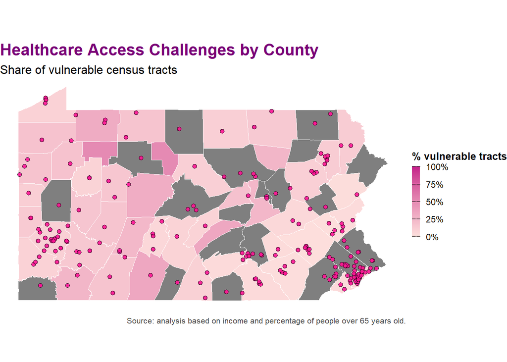

```r
# Create county-level access map
# counties by percentage of vulnerable tracts that are underserved

library(ggplot2)

counties_stat_sf <- pa_counties %>%
  select(COUNTY_NAM, geometry) %>%
  left_join(counties_stat, by = "COUNTY_NAM")

map1 <- ggplot() +
  # county base map
  geom_sf(
    data = counties_stat_sf,
    aes(fill = percentage_vuln),
    color = "white", size = 0.2
  ) +
  # hospitals
  geom_sf(
    data = hospitals_proj,
    shape = 21, fill = "deeppink",
    size = 1.8, alpha = 0.9
  ) +
  # pink color scale
  scale_fill_gradient(
    name = "% vulnerable tracts",
    low = "#fde0dd",     # light pink
    high = "#c51b8a",    # deep magenta
    labels = label_percent(accuracy = 1),
    limits = c(0, 1)
  ) +
  coord_sf() +
  theme_void(base_size = 12) +
  theme(
    legend.position = "right",
    legend.title = element_text(size = 10, face = "bold"),
    legend.text  = element_text(size = 9),
    plot.title   = element_text(face = "bold", size = 16, color = "#7a0177"),
    plot.subtitle= element_text(size = 12),
    plot.caption = element_text(size = 8, color = "gray30")
  ) +
  labs(
    title    = "Healthcare Access Challenges by County",
    subtitle = "Share of vulnerable census tracts",
    caption  = "Source: analysis based on income and percentage of people over 65 years old."
  ) +
  guides(fill = guide_colorbar(
    barheight = unit(70, "pt"),
    barwidth  = unit(8,  "pt"),
    ticks.colour = "black"
  ))

map1
```

**Requirements:** - Fill counties by percentage of vulnerable tracts that are underserved - Include hospital locations as points - Use an appropriate color scheme - Include clear title, subtitle, and caption - Use `theme_void()` or similar clean theme - Add a legend with formatted labels

### Map 2: Detailed Vulnerability Map

Create a map highlighting underserved vulnerable tracts.

**Your Task:**

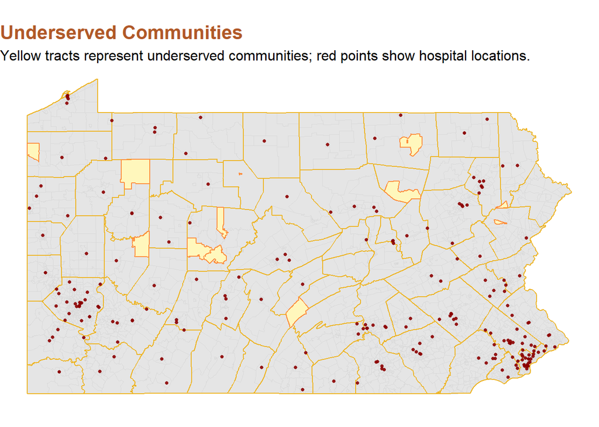

```r
# Create detailed tract-level map

map2 <- ggplot() +
  # tract base map
  geom_sf(
    data = census_tracts,
    color = "grey85", size = 0.1
  ) +
  # county boundaries
  geom_sf(
    data = pa_counties,
    color = "goldenrod2", size = 0.5, fill = NA
  ) +
  # hospitals
  geom_sf(
    data = hospitals_proj,
    shape = 16, color = "darkred",
    size = 1, alpha = 0.9
  ) +
  # underserved communities (highlighted in yellow)
  geom_sf(
    data = undeserved,
    fill = "#fff7bc",
    color = "#fd8d3c",
    size = 0.4
  ) +
  coord_sf() +
  theme_void(base_size = 12) +
  theme(
    plot.title   = element_text(face = "bold", size = 16, color = "#b15928"),
    plot.subtitle= element_text(size = 12),
    plot.caption = element_text(size = 8, color = "gray30")
  ) +
  labs(
    title    = "Underserved Communities",
    subtitle = "Yellow tracts represent underserved communities; red points show hospital locations."
  ) +
  guides(fill = guide_colorbar(
    barheight = unit(70, "pt"),
    barwidth  = unit(8,  "pt"),
    ticks.colour = "black"
  ))


map2
```

**Requirements:** - Show underserved vulnerable tracts in a contrasting color - Include county boundaries for context - Show hospital locations - Use appropriate visual hierarchy (what should stand out?) - Include informative title and subtitle

### Chart: Distribution Analysis

Create a visualization showing the distribution of distances to hospitals for vulnerable populations.

**Your Task:**

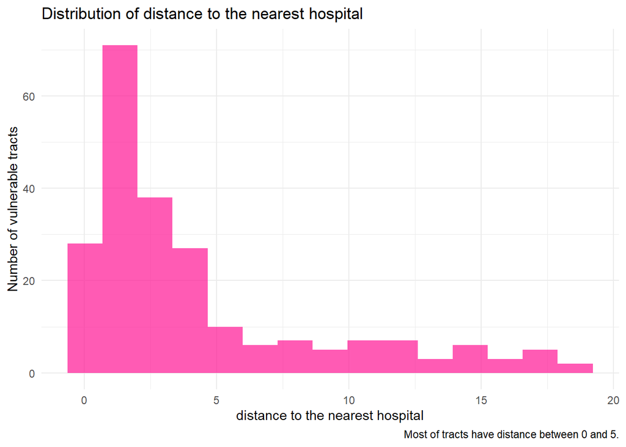

```r
# Create distribution visualization

# Histogram or density plot of distances
ggplot(vulnerable_tracts_proj) +
  aes(x = dist_to_hospital_mi) +
  geom_histogram(bins = 15, fill = "deeppink", alpha = 0.7) +
  labs(
    title = "Distribution of distance to the nearest hospital",
    x = "distance to the nearest hospital",
    y = "Number of vulnerable tracts",
    caption  = "Most of tracts have distance between 0 and 5."
  ) +
  theme_minimal()
```

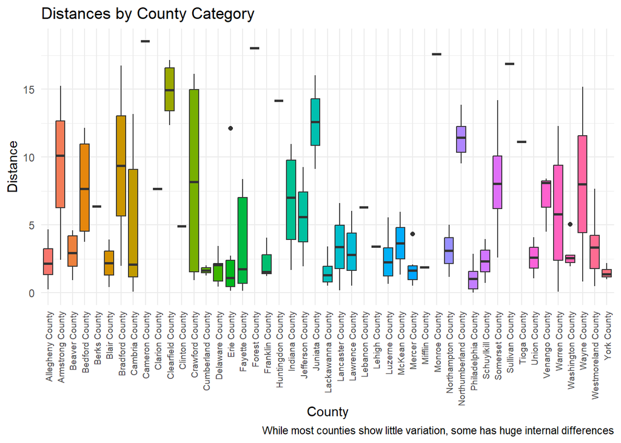

```r
# Box plot comparing distances across regions
ggplot(vulnerable_tracts_proj) +
  aes(x = NAMELSADCO, y = dist_to_hospital_mi, fill = NAMELSADCO) +
  geom_boxplot() +
  labs(
    title = "Distances by County Category",
    x = "County",
    y = "Distance",
    caption  = "While most counties show little variation, some has huge internal differences"
  ) +
  theme_minimal() +
  theme(legend.position = "none")+
  theme(
  axis.text.x = element_text(angle = 90, vjust = 0.5, hjust = 1, size = 7)
)
```

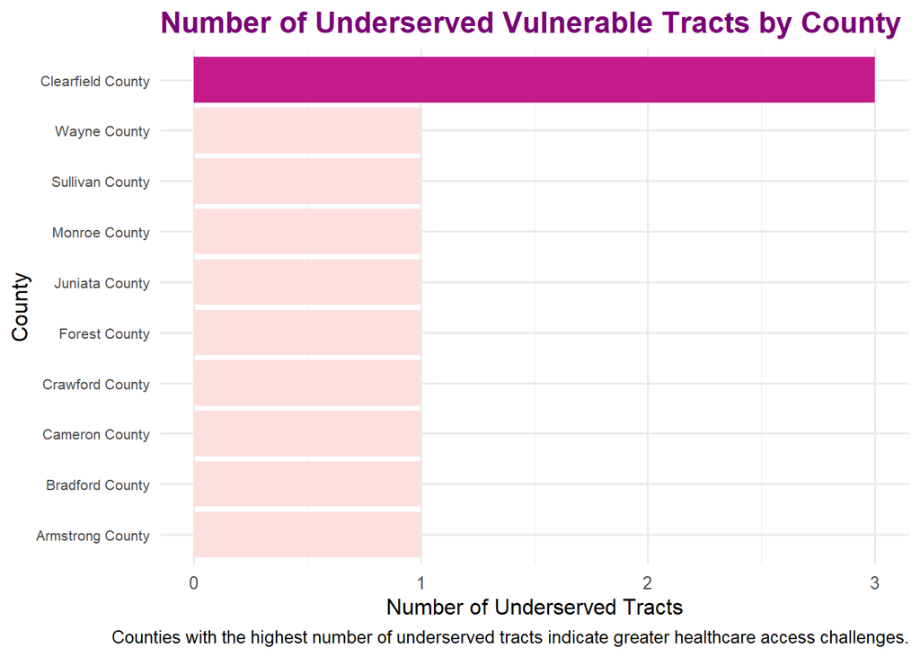

```r
# Bar chart of underserved tracts by county
# Aggregate number of underserved tracts per county
underserved_by_county <- undeserved %>%
  st_drop_geometry() %>%
  group_by(NAMELSADCO) %>%
  summarise(n_underserved = n()) %>%
  arrange(desc(n_underserved))

ggplot(underserved_by_county) +
  aes(x = reorder(NAMELSADCO, n_underserved), y = n_underserved, fill = n_underserved) +
  geom_col(show.legend = FALSE) +
  coord_flip() +
  scale_fill_gradient(low = "#fde0dd", high = "#c51b8a") +
  labs(
    title = "Number of Underserved Vulnerable Tracts by County",
    x = "County",
    y = "Number of Underserved Tracts",
    caption = "Counties with the highest number of underserved tracts indicate greater healthcare access challenges."
  ) +
  theme_minimal(base_size = 12) +
  theme(
    plot.title = element_text(face = "bold", size = 16, color = "#7a0177"),
    plot.subtitle = element_text(size = 12),
    axis.text.y = element_text(size = 8)
  )
```

[figure not shown]

```r
# Scatter plot of distance vs. vulnerable population size
ggplot(vulnerable_tracts_proj) +
  aes(x = dist_to_hospital_mi, y = total_populationE) +
  geom_point(color = "deeppink", alpha = 0.6, size = 2) +
  geom_smooth(
    method = "lm",
    se = TRUE,
    color = "darkred",
    fill = "pink",
    linewidth = 1
  ) +
  labs(
    title = "distance vs. vulnerable population size",
    x = "Distance to the nearest hospital",
    y = "Vulnerable population size",
    caption  = str_wrap("More vulnerable population, little distance to hospital. Since hospitals are designed to located near population clusters, and we didn't limit this effect in this study ", width = 90)
  ) +
  theme_minimal() +
  scale_x_continuous() +
  scale_y_continuous(labels = comma)
```

**Suggested chart types:** - Histogram or density plot of distances - Box plot comparing distances across regions - Bar chart of underserved tracts by county - Scatter plot of distance vs. vulnerable population size

**Requirements:** - Clear axes labels with units - Appropriate title - Professional formatting - Brief interpretation (1-2 sentences as a caption or in text)

## Part 3: Bring Your Own Data Analysis

Choose your own additional spatial dataset and conduct a supplementary analysis.

### Challenge Options

Choose ONE of the following challenge exercises, or propose your own research question using OpenDataPhilly data (https://opendataphilly.org/datasets/).

**Note these are just loose suggestions to spark ideas - follow or make your own as the data permits and as your ideas evolve. This analysis should include bringing in your own dataset, ensuring the projection/CRS of your layers align and are appropriate for the analysis (not lat/long or geodetic coordinate systems). The analysis portion should include some combination of spatial and attribute operations to answer a relatively straightforward question**

#### Education & Youth Services

**Option A: Educational Desert Analysis** - **Data:** Schools, Libraries, Recreation Centers, Census tracts (child population) - **Question:** “Which neighborhoods lack adequate educational infrastructure for children?” - **Operations:** Buffer schools/libraries (0.5 mile walking distance), identify coverage gaps, overlay with child population density - **Policy relevance:** School district planning, library placement, after-school program siting

**Option B: School Safety Zones** - **Data:** Schools, Crime Incidents, Bike Network - **Question:** “Are school zones safe for walking/biking, or are they crime hotspots?” - **Operations:** Buffer schools (1000ft safety zone), spatial join with crime incidents, assess bike infrastructure coverage - **Policy relevance:** Safe Routes to School programs, crossing guard placement

#### Environmental Justice

**Option C: Green Space Equity** - **Data:** Parks, Street Trees, Census tracts (race/income demographics) - **Question:** “Do low-income and minority neighborhoods have equitable access to green space?” - **Operations:** Buffer parks (10-minute walk = 0.5 mile), calculate tree canopy or park acreage per capita, compare by demographics - **Policy relevance:** Climate resilience, environmental justice, urban forestry investment —

#### Public Safety & Justice

**Option D: Crime & Community Resources** - **Data:** Crime Incidents, Recreation Centers, Libraries, Street Lights - **Question:** “Are high-crime areas underserved by community resources?” - **Operations:** Aggregate crime counts to census tracts or neighborhoods, count community resources per area, spatial correlation analysis - **Policy relevance:** Community investment, violence prevention strategies —

#### Infrastructure & Services

**Option E: Polling Place Accessibility** - **Data:** Polling Places, SEPTA stops, Census tracts (elderly population, disability rates) - **Question:** “Are polling places accessible for elderly and disabled voters?” - **Operations:** Buffer polling places and transit stops, identify vulnerable populations, find areas lacking access - **Policy relevance:** Voting rights, election infrastructure, ADA compliance

#### Health & Wellness

**Option F: Recreation & Population Health** - **Data:** Recreation Centers, Playgrounds, Parks, Census tracts (demographics) - **Question:** “Is lack of recreation access associated with vulnerable populations?” - **Operations:** Calculate recreation facilities per capita by neighborhood, buffer facilities for walking access, overlay with demographic indicators - **Policy relevance:** Public health investment, recreation programming, obesity prevention

#### Emergency Services

**Option G: EMS Response Coverage** - **Data:** Fire Stations, EMS stations, Population density, High-rise buildings - **Question:** “Are population-dense areas adequately covered by emergency services?” - **Operations:** Create service area buffers (5-minute drive = ~2 miles), assess population coverage, identify gaps in high-density areas - **Policy relevance:** Emergency preparedness, station siting decisions

#### Arts & Culture

**Option H: Cultural Asset Distribution** - **Data:** Public Art, Museums, Historic sites/markers, Neighborhoods - **Question:** “Do all neighborhoods have equitable access to cultural amenities?” - **Operations:** Count cultural assets per neighborhood, normalize by population, compare distribution across demographic groups - **Policy relevance:** Cultural equity, tourism, quality of life, neighborhood identity

### Data Sources

**OpenDataPhilly:** https://opendataphilly.org/datasets/ - Most datasets available as GeoJSON, Shapefile, or CSV with coordinates - Always check the Metadata for a data dictionary of the fields.

**Additional Sources:** - **Pennsylvania Open Data:** https://data.pa.gov/ - **Census Bureau (via tidycensus):** Demographics, economic indicators, commute patterns - **TIGER/Line (via tigris):** Geographic boundaries

### Recommended Starting Points

**If you’re feeling confident:** Choose an advanced challenge with multiple data layers. **If you are a beginner, choose something more manageable that helps you understand the basics**

**If you have a different idea:** Propose your own question! Just make sure: - You can access the spatial data - You can perform at least 2 spatial operations

### Your Analysis

**Your Task:**

1. **Find and load additional data**
   - Document your data source
   - Check and standardize the CRS
   - Provide basic summary statistics

```r
# Load your additional dataset
library(sf)

schools <- st_read("C:/NATAN/PENN/2025 FALL/Public Policy Analytics/portfolio-setup-itsnatani-humaira/assignments/assignment2/scripts/data/Schools.shp")
crime <- st_read("C:/NATAN/PENN/2025 FALL/Public Policy Analytics/portfolio-setup-itsnatani-humaira/assignments/assignment2/scripts/data/incidents_part1_part2/incidents_part1_part2.shp")
```

```
replacing null geometries with empty geometries
Simple feature collection with 120567 features and 13 fields (with 4991 geometries empty)
Geometry type: POINT
Dimension:     XY
Bounding box:  xmin: -75.27421 ymin: 5.684342e-14 xmax: 5.684342e-14 ymax: 40.13683
Geodetic CRS:  WGS 84
```

```r
bike_network <- crime <- st_read("C:/NATAN/PENN/2025 FALL/Public Policy Analytics/portfolio-setup-itsnatani-humaira/assignments/assignment2/scripts/data/Bike_Network/Bike_Network.shp")
```

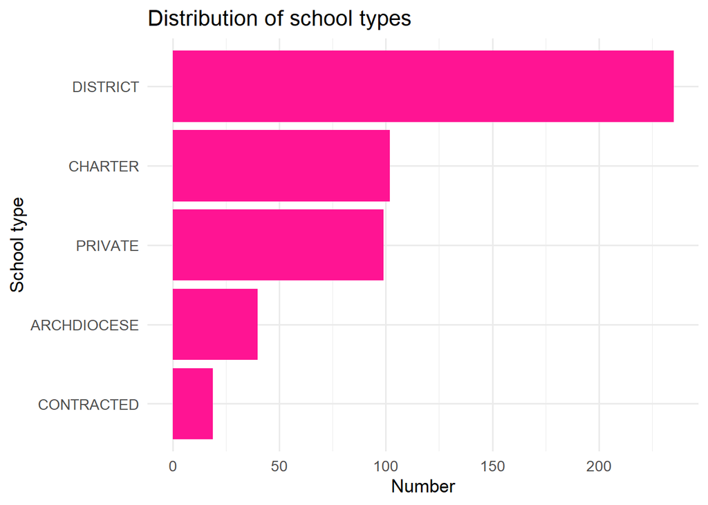

```r
schools <- st_transform(schools, 2272)
crime <- st_transform(crime, 2272)
bike_network <- st_transform(bike_network, 2272)

library(dplyr)
library(ggplot2)

## school type
schools %>%
  st_drop_geometry() %>%
  count(type_speci, sort = TRUE) %>%
  ggplot(aes(x = reorder(type_speci, n), y = n)) +
  geom_bar(stat = "identity", fill = "deeppink") +
  coord_flip() +
  labs(
    title = "Distribution of school types",
    x = "School type",
    y = "Number"
  ) +
  theme_minimal(base_size = 13)
```

[figure not shown]

```r
# Crime Location
crime %>%
  st_drop_geometry() %>%
  count(STREETNAME) %>%
  slice_max(order_by = n, n = 10) %>%       # top 10 streets
  ggplot(aes(x = reorder(STREETNAME, n), y = n)) +
  geom_col(fill = "pink") +
  coord_flip() +                            # flip for readability
  labs(
    title = "Top 10 Streets by Number of Crime Incidents",
    x = "Street",
    y = "Number of Incidents"
  ) +
  theme_minimal(base_size = 13) +
  theme(
    plot.title = element_text(face = "bold"),
    axis.text.y = element_text(size = 10)
  )
```

[figure not shown]

```r
#crime types
crime %>%
  st_drop_geometry() %>%
  count(TYPE, sort = TRUE) %>%
  slice_max(n, n = 10) %>%
  ggplot(aes(x = reorder(TYPE, n), y = n)) +
  geom_bar(stat = "identity", fill = "pink") +
  coord_flip() +
  labs(
    title = "Top 10 Crime Types",
    x = "Types",
    y = "Number of incidents"
  ) +
  theme_minimal(base_size = 13)
```

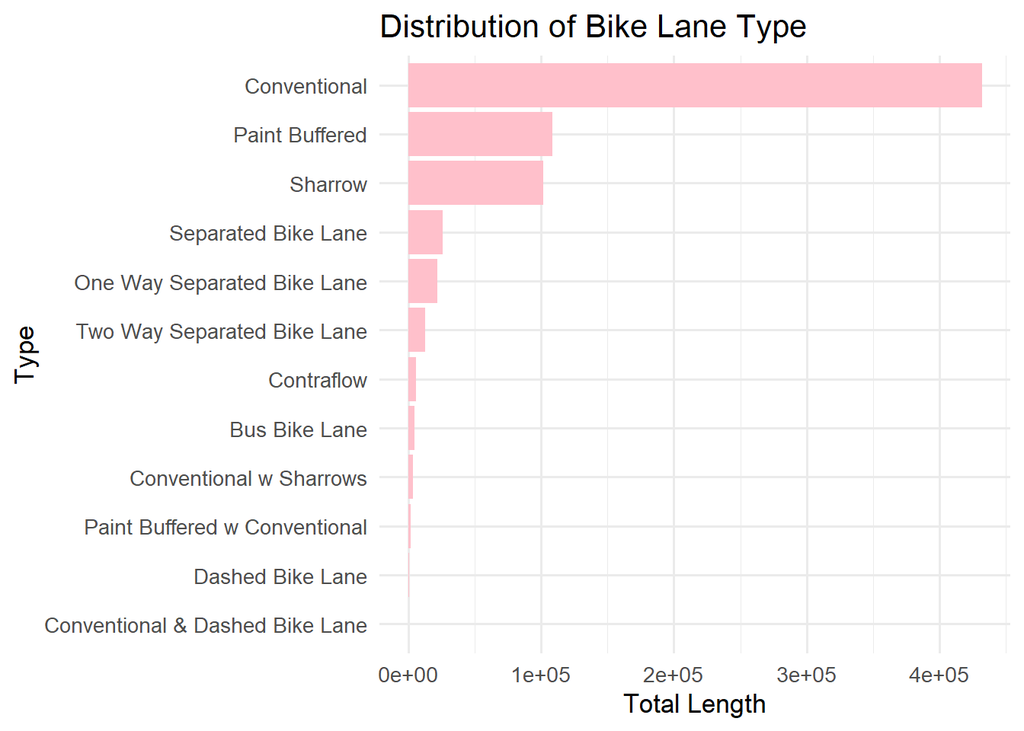

```r
# Bike lane
bike_length_summary <- bike_network %>%
  st_drop_geometry() %>%
  group_by(TYPE) %>%
  summarise(total_length = sum(Shape__Len, na.rm = TRUE)) %>%
  arrange(desc(total_length))

ggplot(bike_length_summary, aes(x = reorder(TYPE, total_length), y = total_length)) +
  geom_bar(stat = "identity", fill = "pink") +
  coord_flip() +
  labs(
    title = "Distribution of Bike Lane Type",
    x = "Type",
    y = "Total Length"
  ) +
  theme_minimal(base_size = 13)
```

2. **Pose a research question**

“Are school zones safe for walking/biking, or are they crime hotspots?”

3. **Conduct spatial analysis**

Use at least TWO spatial operations to answer your research question.

**Required operations (choose 2+):** - Buffers - Spatial joins - Spatial filtering with predicates - Distance calculations - Intersections or unions - Point-in-polygon aggregation

**Your Task:**

```r
# Your spatial analysis
# Create school buffers of 500 meters ≈ 1640 feet
school_buffers <- st_buffer(schools, dist = 1640)

# Find crimes within school buffers
crime_near_schools <- st_join(crime, school_buffers, join = st_intersects, left = FALSE)

# Summarize crimes per school
crime_summary <- crime_near_schools %>%
  st_drop_geometry() %>%
  count(SCHOOL_NAME = school_nam, sort = TRUE)

head(crime_summary, 10)
```

```
                                      SCHOOL_NAME   n
1                           FREIRE CHARTER SCHOOL 150
2                             PHILADELPHIA SCHOOL 104
3                               REVOLUTION SCHOOL  86
4                    GREENFIELD, ALBERT M. SCHOOL  85
5                                            <NA>  75
6                                K012 KIDS SCHOOL  74
7            MARIAN ANDERSON NEIGHBORHOOD ACADEMY  74
8  PARKWAY CENTER CITY MIDDLE COLLEGE HIGH SCHOOL  74
9                   BARRY, JOHN ELEMENTARY SCHOOL  72
10                   FOLK ARTS CULTURAL TREASURES  72
```

```r
# Compare crimes inside vs outside school zones
crime$in_school_zone <- lengths(st_intersects(crime, school_buffers)) > 0

crime %>%
  st_drop_geometry() %>%
  count(in_school_zone) %>%
  mutate(percent = n / sum(n) * 100)
```

```
  in_school_zone    n  percent
1          FALSE  984 18.83254
2           TRUE 4241 81.16746
```

```r
# Overlay bike network with school zones
bike_near_schools <- st_intersection(bike_network, school_buffers)
crime_on_bikelanes <- st_join(crime, bike_near_schools, join = st_intersects, left = FALSE) %>%
  distinct(geometry, .keep_all = TRUE)
```

[figure not shown]

```r
library(ggplot2)
library(sf)

# Map
ggplot() +
  # School buffers
  geom_sf(data = school_buffers, fill = "#fde0dd", color = "#c51b8a", alpha = 0.4) +
  # Schools
  geom_sf(data = schools, shape = 21, fill = "deeppink", color = "white", size = 2) +
  # Crimes
  geom_sf(data = crime, shape = 16, color = "red", alpha = 0.6, size = 1) +
  # Optional: bike lanes
  geom_sf(data = bike_network, color = "goldenrod2", size = 0.6, alpha = 0.7) +
  coord_sf() +
  theme_minimal(base_size = 12) +
  labs(
    title = "Crime Incidents and School Buffers in Philadelphia",
    subtitle = "Pink circles = schools; shaded areas = 500m buffers (~1640 ft); red dots = crime incidents; gold = bike lanes",
    caption = "Data: OpenDataPhilly, 2025"
  )
```

```r
library(dplyr)
library(ggplot2)

# Spatial join: assign crimes to schools via buffer intersection
crime_with_school <- st_join(crime, school_buffers, join = st_intersects, left = FALSE)

# Count number of crimes per school
school_crime_counts <- crime_with_school %>%
  st_drop_geometry() %>%
  group_by(SCHOOL_NAME = school_nam) %>%
  summarise(crime_count = n()) %>%
  arrange(desc(crime_count))

# View top 10 schools with most nearby crimes
head(school_crime_counts, 10)
```

```
# A tibble: 10 × 2
   SCHOOL_NAME                                    crime_count
   <chr>                                                <int>
 1 FREIRE CHARTER SCHOOL                                  150
 2 PHILADELPHIA SCHOOL                                    104
 3 REVOLUTION SCHOOL                                       86
 4 GREENFIELD, ALBERT M. SCHOOL                            85
 5 <NA>                                                    75
 6 K012 KIDS SCHOOL                                        74
 7 MARIAN ANDERSON NEIGHBORHOOD ACADEMY                    74
 8 PARKWAY CENTER CITY MIDDLE COLLEGE HIGH SCHOOL          74
 9 BARRY, JOHN ELEMENTARY SCHOOL                           72
10 FOLK ARTS CULTURAL TREASURES                            72
```

[figure not shown]

```r
# Create points on surface for each school buffer
zone_points <- school_buffers %>%
  left_join(school_crime_counts, by = c("school_nam" = "SCHOOL_NAME")) %>%
  mutate(
    geometry = st_point_on_surface(geometry)  # one point per buffer
  ) %>%
  st_as_sf()

# Get tracts of Philly
tracts_phl <- get_acs(
  geography = "tract",
  state     = "PA",
  county    = "Philadelphia",
  variables = "B01003_001",
  survey    = "acs5",
  year      = 2022,
  geometry  = TRUE,
  cache_table = TRUE
) %>%
  select(GEOID, NAME, pop = estimate, geometry) %>%
  st_transform(2272)

# Map: crime counts by school zone
ggplot() +
  # base map: Philadelphia tracts
  geom_sf(data = tracts_phl, fill = NA, color = "grey70", linewidth = 0.2) +
  # school zone points sized by crime count
  geom_sf(data = zone_points, aes(size = crime_count), color = "firebrick", alpha = 0.6) +
  scale_size_continuous(name = "Crime Count", range = c(1, 6)) +
  labs(
    title = "Crime Counts Around School Zones",
    subtitle = "Point size represents number of crimes within 500m (~1640 ft) of each school",
    x = NULL,
    y = NULL
  ) +
  theme_minimal(base_size = 13) +
  theme(legend.position = "right")
```

**Analysis requirements:** - Clear code comments explaining each step - Appropriate CRS transformations - Summary statistics or counts - At least one map showing your findings - Brief interpretation of results (3-5 sentences)

**Your interpretation:**

Policy Implications:

- Safe Routes to School programs could guide students along safer pathways.
- Crossing guards, improved lighting, and increased supervision at key intersections may help reduce risk.
- Targeted interventions on bike lanes near schools could further enhance walking and biking safety for students.

## Finally - A few comments about your incorporation of feedback!

I’ve hidden my API key this time and printed the output only to the console, not in the Markdown.

## Submission Requirements

**What to submit:**

1. **Rendered HTML document posted to your course portfolio** with all code, outputs, maps, and text
   - Use `embed-resources: true` in YAML so it’s a single file
   - All code should run without errors
   - All maps and charts should display correctly

**File naming:** `LastName_FirstName_Assignment2.html` and `LastName_FirstName_Assignment2.qmd`